# Lab 2

Mia Dawson, GEO200CN, Spring 2017

## Instructions

**Carefully read chapter 7 to 14 in http://rspatial.org/intr/**

**1) Functions+Apply**

1. Use the files from lab 1 to compute mean values for each variable using ‘apply’
2. Write a function ‘f’ that behaves like this:

> f(‘Sarah’) [1] “hello Sarah, how are you”
3. Write a function ‘sumOfSquares’ that behaves like this:

> d <- c(1,5,2,4,6,2,4,5) sumOfSquares(d) [1] 21.875

To compute the “sum of squares”, subtract the mean value of all numbers from each number. Square these numbers and sum them

**2) Data preparation+exploration**. Use the data in “students.csv” and “scores.dat” to assess if there is a relation between the “group” or “age” of a student and their average score and for the three subjects (math, english, geography)

1. use reshape and merge to combine the two data sets
2. compute correlation coefficients
3. produce a relevant plot

**Hand in the results for #1 and #2 as a R Markdown file.** Both the source file and an HTML file. You can complete the .Rmd file available on smartsite.

## Results

**1) Functions+Apply**

1. Use the files from lab 1 to compute mean values for each variable using ‘apply’

```r
datapath = "/users/miadawson/Documents/~UC Davis~/~GEO 200CN/labs/lab 2" #assign directory location to an object called datapath
ChickWeights = read.csv((file.path(datapath, "ChickWeightSub.csv"))) #read provided csv and assign to an object
loblolly = read.delim((file.path(datapath, "loblolly.dat")), sep = " ") #read provided .dat and assign to an object
apply(ChickWeights, 2, mean) #calculate means for all variables in ChickWeights
```

```
##     Weight     DayOld    ChickID     DietID
## 106.833333   9.000000  27.777778   2.333333
```

```r
apply(loblolly, 2, mean) #calculate means for all variables in loblolly
```

```
##   height      age     Seed
##  32.3644  13.0000 316.1429
```

2. Write a function ‘f’ that behaves like this:

> f(‘Sarah’) [1] “hello Sarah, how are you”

```r
f <- function(name) {
  x <- paste('hello ', name,', how are you', sep ="")
  return(x)
} #create function

f('Sarah') #run function
```

```
## [1] "hello Sarah, how are you"
```

3. Write a function ‘sumOfSquares’ that behaves like this:

> d <- c(1,5,2,4,6,2,4,5) sumOfSquares(d) [1] 21.875

To compute the “sum of squares”, subtract the mean value of all numbers from each number. Square these numbers and sum them

```r
d <- c(1,5,2,4,6,2,4,5)

sumOfSquares = function(a) {
  b = sum((a - mean(a))^2)
  return(b)
} #create function

sumOfSquares(d) #run function
```

```
## [1] 21.875
```

**2) Data preparation+exploration**. Use the data in “students.csv” and “scores.dat” to assess if there is a relation between the “group” or “age” of a student and their average score and for the three subjects (math, english, geography)

1. use reshape and merge to combine the two data sets

```r
students = read.csv((file.path(datapath, "students.csv"))) #read provided csv and assign to an object
scores = read.delim((file.path(datapath, "scores.dat")), sep = " ") #read provided .dat and assign to an object
new.scores = reshape(scores, idvar = "student", timevar="subject", direction = "wide") #reshape scores data to wide format so that each row corresponds to a student
names(students)[1]="student" #rename student column in students data frame to match scores data frame
student.scores = merge(students, new.scores) #merge data sets
```

2. compute correlation coefficients

```r
student.scores[student.scores==-999.0]=NA #remove -999 values and replace w NA
student.scores$means=(student.scores$score.math + student.scores$score.english + student.scores$score.geography)/3 #create column for mean scores
cor(student.scores$score.math, student.scores$age, use = "complete.obs") #correlation between math score and age
```

```
## [1] -0.1414865
```

```r
cor(student.scores$score.english, student.scores$age, use = "complete.obs") #correlation between english score and age
```

```
## [1] 0.4657179
```

```r
cor(student.scores$score.geography, student.scores$age, use = "complete.obs") #correlation between geography score and age
```

```
## [1] -0.192527
```

```r
cor(student.scores$means, student.scores$age, use = "complete.obs") #correlation between mean scores and age
```

```
## [1] 0.03800345
```

3. produce a relevant plot

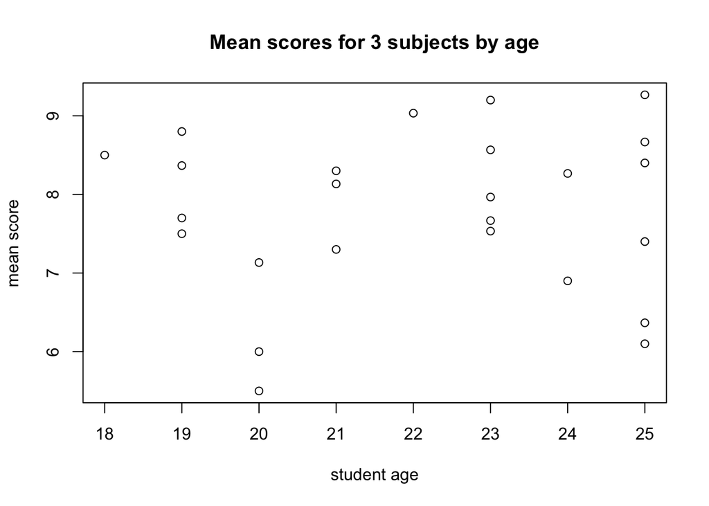

```r
plot(student.scores$means~student.scores$age, main = "Mean scores for 3 subjects by age", xlab="student age", ylab="mean score") #create scatterplot
```